# Tweets analysis: #trump vs #biden

9/06/2021

## Introduzione

## Introduzione

[figure not shown]

Con la nascita del web 2.0 il dibattito politico si è spostato sui social che sono un indicatore importante di ciò che viene percepito dall’opinione pubblica.  
Un caso virale di questa situazione è il dibattito tra l’ex presidente Trump e il neo presidente Biden.  
Twitter permette facilmente di ottentere i dati e analizzare:

1. Le parole più utilizzate sul dibattito;
2. Gli utenti e gli hashtag correlati;
3. Le emozioni espresse;

## Cosa scrivono gli utenti di Twitter su Biden e Trump?

## Prima osservazione

I dati si riferiscono ad un campione di 1000 tweet che contengono #biden e altrettanti con #trump.

Le parole più utilizzate:

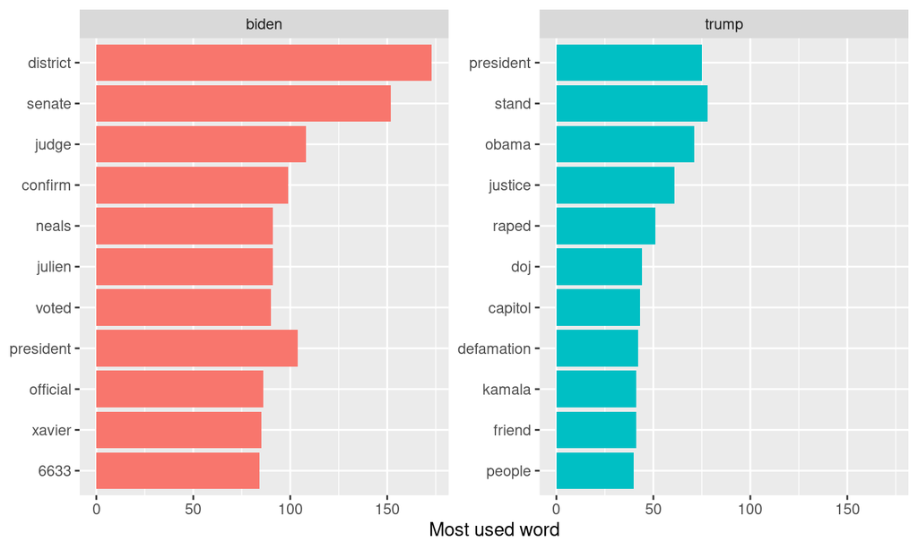

Dal grafico si nota che:

1. Si nota la presenza di altre personalità politiche come Kamala Harris e Obama;
2. Sono presenti altri termini politici.
3. È presente anche un numero 6633.

**Cerchiamo spiegazioni di quel numero.**

## Seconda osservazione

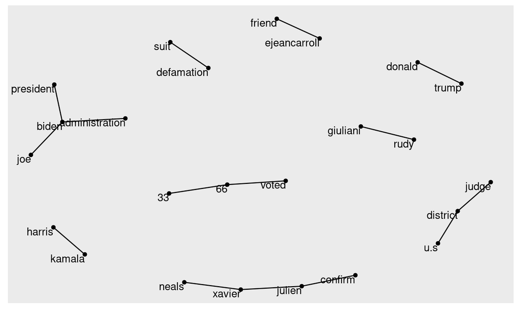

E qui risulta chiaro che il numero era relativo al risultato di una votazione.

**Dal NYT: “On June 8, 2021, his nomination was confirmed by a vote of 66–33. Renomination to district court under Biden”**

1. Si notano infatti relative alla nominazione **judge -> district-> u.s**, **confirm -> julien -> xavier -> neals**
2. Sono presenti altre informazioni poco interessanti come **administration, president**
3. Argomento di interesse del pubblico è stata la richiesta da parte di **rudy -> giuliani**
4. **ejeancarroll -> friend** e **defamation -> suit** è relativo all’accusa contro Trump

## Users citati e hashtag correlati

## Users citati

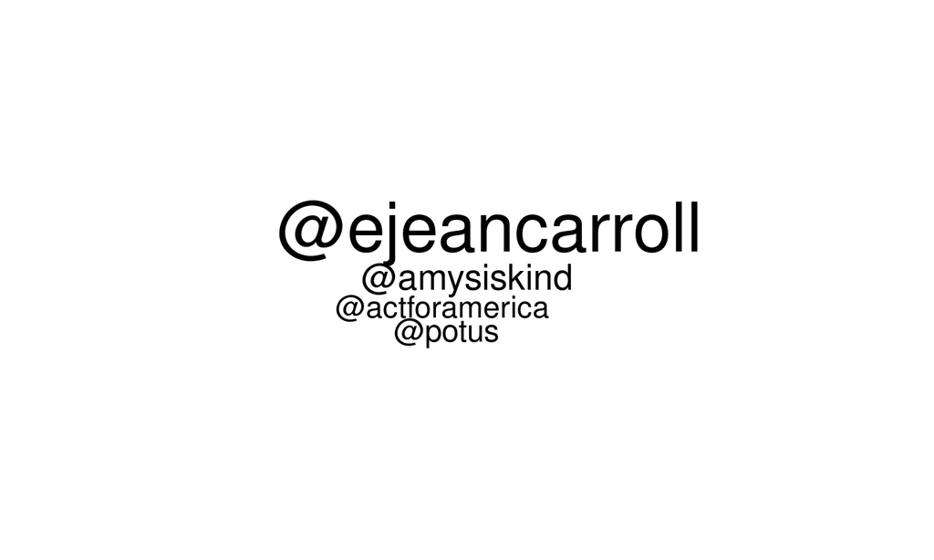

Considerazioni sui @user più citati:

> 1.Sono principalmente giornalisti politici

## Hashtag correlati

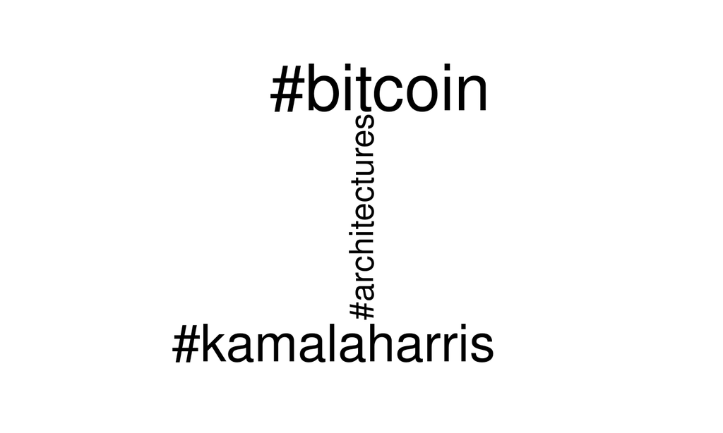

Considerazioni sui #hashtags più citati:

1. Bitcoin

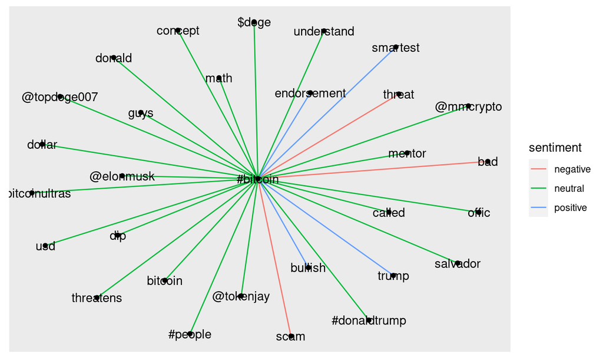

1. Kamala Harris

```
##                       word n
## 1            #kamalaharris 7
## 2                   #biden 5
## 3          @giorgiolaporta 3
## 4                     #tru 3
## 5                  confini 3
## 6                difendano 3
## 7                 problema 3
## 8                    servi 3
## 9                 sinistri 3
## 10                urlavano 3
## 11        @gianmar26145917 2
## 12               #democrat 2
## 13           #ocasiocortez 2
## 14               #sinistra 2
```

[output cut: 23 more lines]

## UTILIZZO DELLE EMOJI

## Utilizzo delle emoji sui Twitter

Per questa analisi, è imprescindibile non analizzare anche l’utilizzo di emoji che è uno strumento di espressione delle emozioni sul social dal 2014. In questa sezione vedremo:

Quali sono le emoji più utilizzate La distribuzione delle emoji per i tweets su #biden e #trump

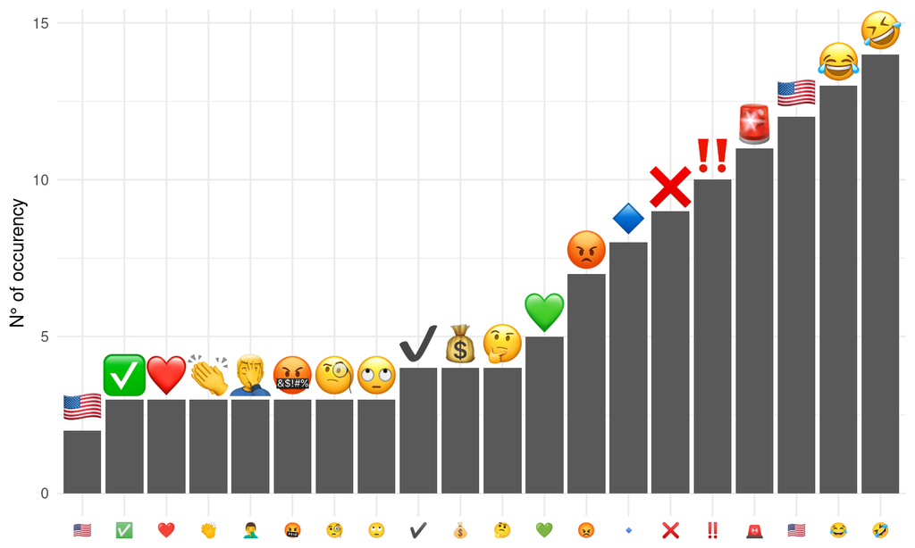

Queste sono le emoji più utilizzate ma come si dividono tra i due hashtag?

## Quali sono le emoji per i singoli hashtag?

## Vediamo le differenze

Per rispondere alla domanda, ho analizzato la frequenza relativa del’utilizzo delle emoji:

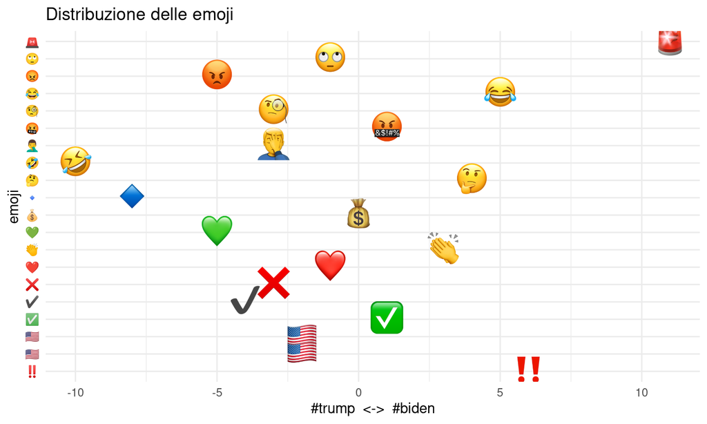

Si osserva la distribuzione:

1. I tweet con **#trump** hanno più risate;
2. I tweet con **#biden** sono invece caratterizzati da punti esclamativi e lampeggianti;

## Sentiment analysis

Utile trovare le emozioni e vedere quali sentimenti si esprimono riguardo ai diversi hashtag come indicatore di ciò che gli utenti pensano o sentono quando si riferiscono ai diversi presidenti.

Ho analizzato le emozioni espresse:

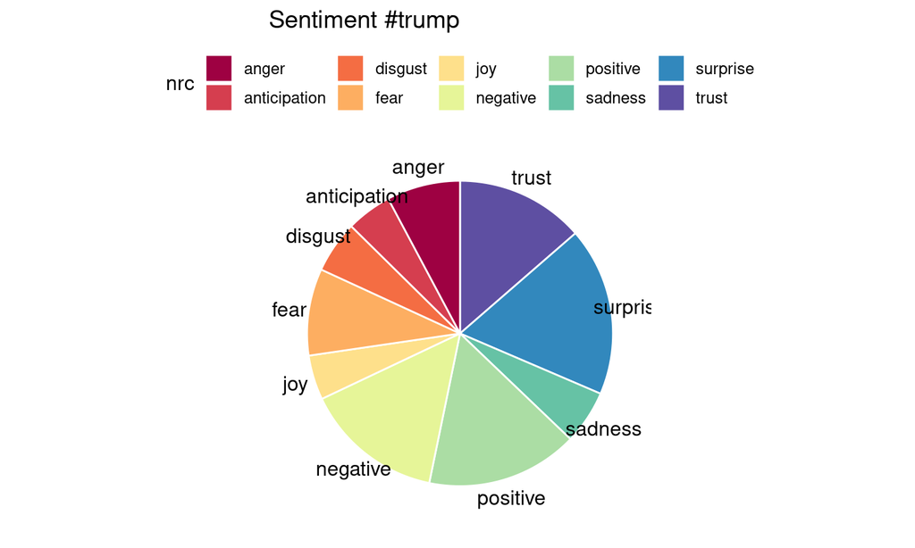

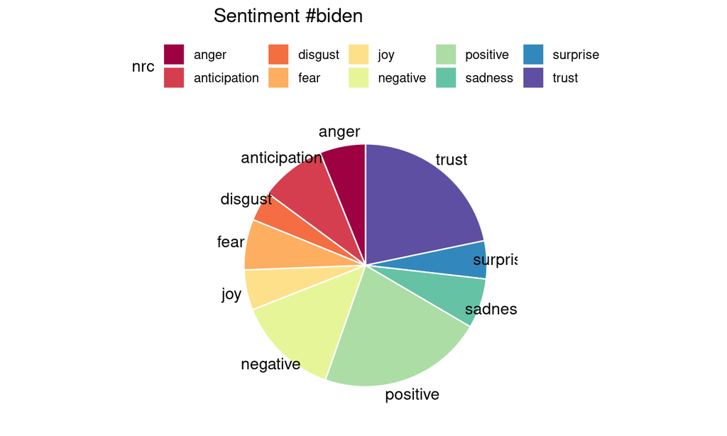

Risulta che:

1. I tweets riguardanti **Trump** hanno in **misura simile** espresso sentimenti **negativi e positivi**, esprimendo invece molta **sorpresa** e a seguire **fiducia**. leggera paura e rabbia.
2. Per quel che riguarda i tweets riguardo **Biden** è presente in maniera preponderante **fiducia e positività**. In maniera **minore** i sentimenti **negativi e attesa**.